### Is the distribution approximately normal?

As discussed previously, we have obtained the sample mean and the sample variance (which gives sample standard deviation(Ssd)). We, therefore, first use the sample mean and the Ssd to plot the normal distribtion on top of the histogram and compare it with the normal distribution obtained using theoretical mean and theoretical sd (Tsd).

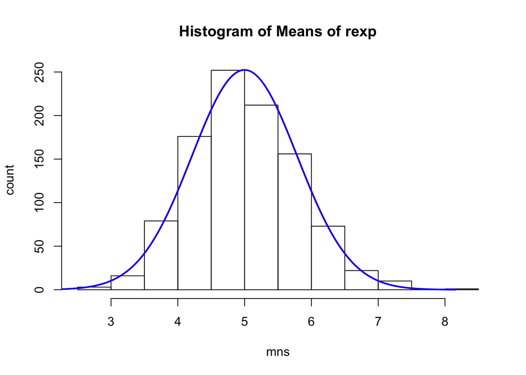

The red curve is obtained based on the sample mean data, including sample mean and sample variance or sample standard deviation. The blue curve is obtained purely based on the theory with theoretical mean and theoretical variance. We can see that for 1000 times of simulations, they match each other quite well, which gives confirms the central limit theorem.

### Appendix: Codes

```r
### Codes for Sample Mean

## We first fix the value of lambda
# lambda <- 0.2

## We create a Null vector called mns
# mns <- c()

## For each i, we generate 40 data using exponential distribution with
## given lambda and calculate the mean of these 40 data and append it
## to the vector mns. We iterate it for 1000 times to generate a distribution.
# for (i in 1:1000) mns <- c(mns, mean(rexp(40,lambda)))

## Let's first show the distribution and calculate the sample mean
# hist(mns, xlab = "mns", ylab = "count", main = "Histogram of Means of rexp", breaks = 20)

## We add a verticle line to illustrate the sample mean
# abline( v = mean(mns), col=2, lwd =2)

## The mean of the distribution gives the sample mean
#samplemean <- mean(mns)



### Codes for Sample Variance versus Theoretical Variance
## The theoretical var can be obtained from the exponetial distribution
# Tvar <- 1/(lambda^2)/40

## The sample var is
# Svar <- var(mns)

## In order to compare Tvar and Svar using some plots, we can look at the
## standard deviation of the sample mean distribution which is
## basically the square root of the sample variance.
# hist(mns, xlab = "mns", ylab = "count", main = "Histogram of Means of rexp",
# breaks = 20)

## illustrate the theoretical sample sd
# abline( v = samplemean + sqrt(Tvar), col=4, lwd = 2)

## the sample sd
# abline( v = samplemean + sqrt(Svar), col=2, lwd = 2)

## illustrate the theoretical sample sd
# abline( v = samplemean - sqrt(Tvar), col=4, lwd = 2)

## the sample sd
# abline( v = samplemean - sqrt(Svar), col=2, lwd = 2)



### Codes for checking the consistence of normal distribution
## Let's first replot the histogram
# ht <- hist(mns, xlab = "mns", ylab = "count", main = "Histogram of Means of rexp",
# breaks = 20)

## The sample sd is as follows
# Ssd <- sqrt(Svar)

## The theoretical sd is
# Tsd <- sqrt(Tvar)

## Nowe we generate the normal distribution data using sample mean and Ssd
## We first generate sequence of data between samplemean +- 4 Ssd which
## should cover >99% data
# xsample<- seq(samplemean - 4*Ssd, samplemean + 4*Ssd, length = 1000)

## generate the normal distribution
# ysample <- dnorm(xsample, mean = samplemean, sd = Ssd)

## Rescale the y value
## Below ht$mids gives the mid points of the bars and diff(ht$mids[1:2])
## gives the difference between the first two mid points which should be
## universal distance between nearby mid points
## We then multiply it by length(xsample) which tells that how many points
## are contained withing each difference between mid points
# ysample <- ysample*diff(ht$mids[1:2])*length(xsample)

## Now we generate the normal distribution data using theoretical mean and Tsd
## Note that theoretical mean is 1/lambda = 5
# xtheo <- seq(1/lambda - 4 *Tsd, 1/lambda + 4 * Tsd, length = 1000)

## general the theoretical normal distribution
# ytheo <- dnorm(xtheo, mean = 1/lambda, sd = Tsd)

## Rescale
# ytheo <- ytheo*diff(ht$mids[1:2])*length(xtheo)

## Now we plot both normal distributions based on sample mean data and theoretical analysis
# lines(xsample,ysample, col =2, lwd = 2) ## sample normal
# lines(xtheo, ytheo, col = 4, lwd = 2) ## theoretical normal
```